# Metody quasi-randomizacyjne: kalibracja

# 1 Wprowadzenie

Wczytujemy pakiet `tidyverse`.

```r
library(tidyverse)
library(knitr)
library(survey)
```

Wczytujemy dane na potrzeby zajęć.

```r
dane <- read_csv("../data/popyt-zajecia-dane.csv") |>
  mutate(zawod_kod2 = factor(zawod_kod2),
         jedna_zmiana=as.numeric(jedna_zmiana))
```

| id_popyt | id_jednostki | waga | sek | klasa_pr | sekc_pkd | woj | zawod_kod2 | wolne_miejsca | id_cbop | jedna_zmiana | wymiar_40 | wolne_miejsca_cbop | wolne_miejsca_niepeln_cbop |
| --- | --- | --- | --- | --- | --- | --- | --- | --- | --- | --- | --- | --- | --- |
| 1 | a9cc990df6a99ab215a1bc13f51d4825c7d52d18 | 1 | 1 | D | O | 14 | 1 | 2 | NA | NA | NA | NA | NA |
| 2 | a9cc990df6a99ab215a1bc13f51d4825c7d52d18 | 1 | 1 | D | O | 14 | 2 | 7 | NA | NA | NA | NA | NA |
| 3 | c9dbaf50890165ebe810aa770de0e9df903dc35b | 6 | 1 | D | O | 24 | 2 | 6 | NA | NA | NA | NA | NA |
| 4 | 718e0bba42bcec6ed98f9690db6d26cb7b93c880 | 1 | 1 | D | R.S | 14 | 2 | 7 | NA | NA | NA | NA | NA |
| 5 | 532a1879a692b9d7bbb7282ba757d028156ef341 | 1 | 1 | D | R.S | 14 | 2 | 6 | NA | NA | NA | NA | NA |
| 6 | 0b6b623fa45e257284a3049d097af322841337e3 | 1 | 1 | D | R.S | 22 | 2 | 1 | NA | NA | NA | NA | NA |

# 2 Przykłady

## 2.1 Opis funkcji `calibrate` z pakietu `survey`

```
calibrate(design, formula, population,
       aggregate.stage=NULL, stage=0, variance=NULL,
       bounds=c(-Inf,Inf), calfun=c("linear","raking","logit"),
       maxit=50,epsilon=1e-7,verbose=FALSE,force=FALSE,trim=NULL,
       bounds.const=FALSE, sparse=FALSE,...)
```

Opis wybranych argumentów:

- `design` – obiekt typu `survey.design`, który tworzymy funkcją `svydesign`,
- `formula` – określamy zmienne wykorzystywane do kalibracji w postaci formuły (np. `~ x1 + x2`, `list(~x1, ~x2)`),
- `population` – dane z populacji (wektor albo lista z wartościami),
- `bounds` – zakres zmienności wag,
- `calfun` – funkcja kalibracyjna,
- `trim` – czy chcemy uciąć ekstremalne wagi.

## 2.2 Przykład z wykorzystaniem pakietu survey

1. Tworzymy podzbiór z potrzebnymi danymi, w której kolumnę `wolne_miejsca_cbop` traktujemy jako wagę wejściową ponieważ jeden wiersz odpowiada za jednen lub więcej wakatów.

```r
dane |>
  filter(is.na(id_popyt)) |>
  select(id_jednostki, klasa_pr, sek, woj, zawod_kod2, wolne_miejsca_cbop, jedna_zmiana) -> cbop_df
```

| id_jednostki | klasa_pr | sek | woj | zawod_kod2 | wolne_miejsca_cbop | jedna_zmiana |
| --- | --- | --- | --- | --- | --- | --- |
| 03950533c4990dd3e6b80312d98d7bf7877d6cdc | D | 1 | 22 | 2 | 1 | 1 |
| fc1e0932170f7ec7da987a060bfb7ab01a928b3f | D | 1 | 14 | 9 | 2 | 1 |
| ec812df7c443d9681645795c35687241418466ea | D | 1 | 12 | 5 | 3 | 0 |
| ec812df7c443d9681645795c35687241418466ea | D | 1 | 12 | 9 | 4 | 1 |
| f59016808a975f0f45ab571899d50d4931cebaeb | D | 1 | 24 | 2 | 2 | 1 |
| 76f26af4360f38e53850ea0628131fd7a8c51a82 | D | 1 | 04 | 2 | 1 | 1 |

2. Tworzymy obiekt `svydesign`

```r
cbop_svy <- svydesign(ids = ~1,
                      weights = ~ wolne_miejsca_cbop,
                      data = cbop_df)
cbop_svy
```

```
Independent Sampling design (with replacement)
svydesign(ids = ~1, weights = ~wolne_miejsca_cbop, data = cbop_df)
```

3. Estymator naiwny na podstawie danych jednostkowych

```r
svymean(~jedna_zmiana, cbop_svy)
```

```
                mean     SE
jedna_zmiana 0.52046 0.0136
```

### 2.2.1 Kalibracja z wykorzystaniem zmiennej `klasa_pr`

1. Wyznaczamy wartości globalne na potrzeby post-stratyfikacji zgodnie z wymogami funkcji `postStratify`

```r
pop_totals <- xtabs(wolne_miejsca*waga ~ klasa_pr, data= dane, subset = !is.na(id_popyt))
pop_totals
```

```
klasa_pr
     D      M      S
 94124 128940  71230
```

2. Dokonujemy kalibracji
- sposób 1 – podajemy wektor z danymi (zwykle w przypadku jednej zmiennej)

```r
cbop_svy_cal <- calibrate(cbop_svy,
                          formula = ~klasa_pr,
                          population = c(`(Intercept)`=sum(pop_totals),
                                         klasa_prM = 128940,
                                         klasa_prS = 71230))
cbop_svy_cal
```

```
Independent Sampling design (with replacement)
calibrate(cbop_svy, formula = ~klasa_pr, population = c(`(Intercept)` = sum(pop_totals),
    klasa_prM = 128940, klasa_prS = 71230))
```

- sposób 2 – podajemy formułę ale musimy zapisać w formie obiektu `list`

```r
cbop_svy_cal <- calibrate(cbop_svy, list(~klasa_pr), population = list(pop_totals))
cbop_svy_cal
```

```
Independent Sampling design (with replacement)
calibrate(cbop_svy, list(~klasa_pr), population = list(pop_totals))
```

3. Estymator kalibracyjny

```r
svymean(~jedna_zmiana, cbop_svy_cal)
```

```
                mean     SE
jedna_zmiana 0.60006 0.0079
```

### 2.2.2 Kalibracja z wykorzystaniem większej liczby zmiennych

1. Wyznaczamy wartości globalne na potrzeby kalibracji zgodnie z wymogami funkcji `calibrate` dla dwóch zmiennych

```r
pop_totals2 <- xtabs(wolne_miejsca*waga ~ klasa_pr + zawod_kod2, data= dane, subset = !is.na(id_popyt))
pop_totals2
```

```
        zawod_kod2
klasa_pr     1     2     3     4     5     7     8     9
       D  4235 22547  9086  8351 13643 16569 13587  6106
       M  5710  8019  7250 11248 23771 40370 22826  9746
       S  1353  8575  3487  7815 14295 16627 10733  8345
```

2. Sprawdzamy dla próby nielosowej

```r
svytable(~ klasa_pr + zawod_kod2, cbop_svy)
```

```
        zawod_kod2
klasa_pr    1    2    3    4    5    7    8    9
       D  185  717  772 1973 1899 2323 1947 3384
       M   37  287  374  322 1574 2185  751 1224
       S   62  753  432  526 1121 1807  927 1200
```

2. Dokonujemy post-stratyfikacji z wykorzystaniem dwóch zmiennych

```r
cbop_svy_cal2 <- calibrate(cbop_svy,
                           formula = list(~klasa_pr + zawod_kod2),
                           population = list(pop_totals2))
cbop_svy_cal2
```

```
Independent Sampling design (with replacement)
calibrate(cbop_svy, formula = list(~klasa_pr + zawod_kod2), population = list(pop_totals2))
```

3. Estymator kalibracyjny

```r
svymean(~jedna_zmiana, cbop_svy_cal2)
```

```
                mean     SE
jedna_zmiana 0.63526 0.0076
```

Może się jednak zdarzyć, że dla określonych zmiennych znamy tylko wartości globalne (marginalne), a nie mamy informacji o rozkładzie łącznym. Poniżej przykład

1. Wartości globalne dla zmiennych `klasa_pr` i `zawod_kod2`

```r
pop_totals_kl <- xtabs(wolne_miejsca*waga ~ klasa_pr, data= dane, subset = !is.na(id_popyt))
pop_totals_za <- xtabs(wolne_miejsca*waga ~ zawod_kod2, data= dane, subset = !is.na(id_popyt))
pop_totals_kl
```

```
klasa_pr
     D      M      S
 94124 128940  71230
```

2. Kalibracja dla takiego przykładu

```r
cbop_svy_cal3 <- calibrate(cbop_svy,
                           formula = list(~klasa_pr, ~zawod_kod2),
                           population = list(pop_totals_kl, pop_totals_za))
cbop_svy_cal3
```

```
Independent Sampling design (with replacement)
calibrate(cbop_svy, formula = list(~klasa_pr, ~zawod_kod2), population = list(pop_totals_kl,
    pop_totals_za))
```

3. Estymator kalibracyjny

```r
svymean(~jedna_zmiana, cbop_svy_cal3)
```

```
                mean     SE
jedna_zmiana 0.62413 0.0078
```

### 2.2.3 Kalibracja ze zmiennymi na różnych poziomach

Poniżej przedstawiam przykład, w którym kalibracji dokonuje się na dwóch różnych poziomach co nie jest możliwe w przypadku post-stratyfikacji. Celem będzie odtworzenie liczby podmiotów według ich wielkości (1 poziom) oraz liczby wakatów według wielkości podmiotów (2 poziom). Czyli będę chciał utworzyć takie wagi aby po ich zsumowaniu uzyskać zgodność zarówno w zakresie wielkości populacji referencyjnej (czyli liczby podmiotów w Polsce), jak i estymowanej liczby wolnych miejsc pracy w tych podmiotach.

Zadanie to wykonane będzie w dwóch krokach:

- Krok 1: Należy dodać zestaw zmiennych określających liczbę wakatów według wielkości podmiotu do zbioru `cbop_df`. Utworzona zostanie również nowa waga odzwierciedlająca liczbę podmiotów, a nie liczbę wakatów.
- Krok 2: Należy utworzyć specjalny wektor, który będzie zawierał wartości globalne z dwóch poziomów.

1a. Określamy wielkość populacji

```r
wielkosc_pop <- sum(dane$waga[!is.na(dane$id_popyt)])
wielkosc_pop
```

```
[1] 61620
```

1b. Dodajemy zmienne 0-1 jedynkowe

UWAGA: zmienna `waga` odnosi się do liczby podmiotów, a nie wakatów!!

```r
cbop_df <- cbop_df %>%
    mutate(wakaty_d = ifelse(klasa_pr == "D", wolne_miejsca_cbop, 0),
           wakaty_m = ifelse(klasa_pr == "M", wolne_miejsca_cbop, 0),
           wakaty_s = ifelse(klasa_pr == "S", wolne_miejsca_cbop, 0),
           waga = wielkosc_pop/n())

head(cbop_df)
```

```
# A tibble: 6 × 11
  id_jednostki   klasa_pr   sek woj   zawod_kod2 wolne_miejsca_cbop jedna_zmiana
  <chr>          <chr>    <dbl> <chr> <fct>                   <dbl>        <dbl>
1 03950533c4990… D            1 22    2                           1            1
2 fc1e0932170f7… D            1 14    9                           2            1
3 ec812df7c443d… D            1 12    5                           3            0
4 ec812df7c443d… D            1 12    9                           4            1
5 f59016808a975… D            1 24    2                           2            1
6 76f26af4360f3… D            1 04    2                           1            1
# ℹ 4 more variables: wakaty_d <dbl>, wakaty_m <dbl>, wakaty_s <dbl>,
#   waga <dbl>
```

Pokazujemy wg czego będziemy kalibrować wagi

```r
total_klasa_pod <- xtabs(waga ~ klasa_pr, dane, subset = !is.na(id_popyt))
total_klasa_wak <- xtabs(waga*wolne_miejsca ~ klasa_pr,dane, subset = !is.na(id_popyt))

cat("===================")
print("Liczba podmiotów:")
```

```
[1] "Liczba podmiotów:"
```

```r
total_klasa_pod
```

```
klasa_pr
    D     M     S
13099 32417 16104
```

```r
cat("===================")
print("Estymowana liczba wakatów:")
```

```
[1] "Estymowana liczba wakatów:"
```

```r
total_klasa_wak
```

```
klasa_pr
     D      M      S
 94124 128940  71230
```

1c. tworzymy nowy obiekt ze zmiennymi utworzonymi powyżej

```r
proba_nielos_svy <- svydesign(ids= ~1, weights = ~waga, data = cbop_df)
svytotal(~wakaty_s, proba_nielos_svy)
```

```
         total     SE
wakaty_s 38347 959.02
```

2. Dokonujemy kalibracji wskazując według których zmiennych kalibrujemy oraz ich wartości globalne

```r
proba_nielos_svy_cal <- calibrate(design = proba_nielos_svy,
                                  formula = ~klasa_pr+wakaty_d+wakaty_m+wakaty_s,
                                  population = c(
                                    "(Intercept)" = sum(total_klasa_pod),  ## liczba podmiotów ogółem
                                    "klasa_prM" = unname(total_klasa_pod[2]), ## liczba podmiotów małych
                                    "klasa_prS" = unname(total_klasa_pod[3]), ## liczba podmiotów srednich
                                    "wakaty_d" = unname(total_klasa_wak[1]), ## liczba wakatów w duzych podmiotach
                                    "wakaty_m" = unname(total_klasa_wak[2]), ## liczba wakatow w małych podmiotach
                                    "wakaty_s" = unname(total_klasa_wak[3])) ## liczba wakatow w średnich podmiotach
                                    )
```

Wyznaczamy liczbę wakatów z wykorzystaniem zmiennej `wolne_miejsca_cbop` według zmiennej `jedna_zmiana`

```r
res <- svyby(~wolne_miejsca_cbop, ~jedna_zmiana, proba_nielos_svy_cal, svytotal)
res
```

```
  jedna_zmiana wolne_miejsca_cbop       se
0            0           118618.8 6066.837
1            1           175675.2 6066.837
```

Ostatecznie interesujący nas odsetek wynosi (co jest wyższe od naiwnego wynoszącego około 52%)

```r
weighted.mean(res$jedna_zmiana,res$wolne_miejsca_cbop)
```

```
[1] 0.5969377
```

# 3 Badanie symulacyjne

## 3.1 Definicja procesu generowania danych

Rozważmy następujący układ:

- Wielkość populacji $N=10000$
- Dwie cechy $X$:

$$\begin{align}
X_1 & \sim \text{Bernoulli}(0.7) \\
X_2 & \sim \text{Bernoulli}(0.9) \\
\end{align}$$
+ Model dla cechy Y

$$Y = 4.5 - 3.5X_1 + 0.5X_2 + \epsilon; \quad \epsilon \sim N(0,1)$$

- Próba nielosowa o wielkości $n_b=1000$ jest generowana proporcjonalnie do cechy $Y$, gdzie prawdopodobieństwo wylosowania danego rekordu określone jest w następujący sposób:

$$P(R_i = 1) = \frac{|y_i|}{\sum_{i=1}^N |y_i|}$$
Dla tak uzyskanej próby nielosowej należy:

- ocenić różnice w rozkładach X między próbą, a populacją,
- ocenić zależność między cechą X1 i X2
- dokonać post-stratyfikacji z wykorzystaniem pakietu `survey`.

## 3.2 Rozwiązanie

Kod R do generowania danych

```r
set.seed(2023)
N <- 10000
nb <- 1000
X1 <- rbinom(N, 1, 0.7)
X2 <- rbinom(N, 1, 0.9)
Y <- 4.5 - 3.5*X1+0.5*X2 + rnorm(N)
nb_inds <- sample(1:N, size = nb, prob = abs(Y)/sum(abs(Y)))
flag <- 1:N %in% nb_inds
w_star <- N/nb ## dodajemy pseudo-wagę jako relację miedzy N / nb
df <- data.frame(Y,X1,X2,flag,w_star)
head(df)
```

```
          Y X1 X2  flag w_star
1 2.6962638  1  0 FALSE     10
2 1.6924790  1  1 FALSE     10
3 0.6321686  1  1 FALSE     10
4 1.2589372  1  1 FALSE     10
5 1.5824627  1  0 FALSE     10
6 2.1429458  1  0 FALSE     10
```

Porównajmy rozkłady $X_1$ i $X_2$

```r
pop_X1 <- mean(df$X1)
pop_X2 <- mean(df$X2)
sam_X1 <- mean(df$X1[df$flag == 1])
sam_X2 <- mean(df$X2[df$flag == 1])
c(X1_pop = pop_X1, X2_pop = pop_X2, X1_proba = sam_X1, X2_proba = sam_X2)
```

```
  X1_pop   X2_pop X1_proba X2_proba
  0.7072   0.9036   0.4510   0.9140
```

Rozkład łączny $X_1$ i $X_2$ – różnica w odsetkach między próbą, a populacją.

```r
prop.table(xtabs(~X1 + X2, df, subset = flag == T)) - prop.table(xtabs(~X1 + X2, df))
```

```
   X2
X1        0       1
  0  0.0259  0.2303
  1 -0.0363 -0.2199
```

Jaka jest zależność między $Y$, a $X_1$ oraz $X_2$?

```r
m1 <- lm(Y ~ X1 + X2, data = df, subset = flag == TRUE)
summary(m1)
```

```
Call:
lm(formula = Y ~ X1 + X2, data = df, subset = flag == TRUE)

Residuals:
     Min       1Q   Median       3Q      Max
-3.09126 -0.67897 -0.04242  0.66475  2.79378

Coefficients:
            Estimate Std. Error t value Pr(>|t|)
(Intercept)  4.76611    0.10602  44.956  < 2e-16 ***
X1          -3.05386    0.06121 -49.893  < 2e-16 ***
X2           0.37289    0.10863   3.433 0.000623 ***
---
Signif. codes:  0 '***' 0.001 '**' 0.01 '*' 0.05 '.' 0.1 ' ' 1

Residual standard error: 0.9616 on 997 degrees of freedom
Multiple R-squared:  0.7141,    Adjusted R-squared:  0.7135
F-statistic:  1245 on 2 and 997 DF,  p-value: < 2.2e-16
```

Funkcją anova możemy sprawdzić jak dana zmienna wpływa na redukcję sumy kwadratów odchyleń (SSQ).

```r
anova(m1)
```

```
Analysis of Variance Table

Response: Y
           Df  Sum Sq Mean Sq  F value    Pr(>F)
X1          1 2291.43 2291.43 2477.928 < 2.2e-16 ***
X2          1   10.90   10.90   11.782 0.0006226 ***
Residuals 997  921.96    0.92
---
Signif. codes:  0 '***' 0.001 '**' 0.01 '*' 0.05 '.' 0.1 ' ' 1
```

Wnioski:

- główna rozbieżność w zmiennej $X_1$, w $X_2$ niezbyt,
- zmienna $X_1$ jest silniej skorelowana z $Y$ niż $X_2$.

Dokonujemy kalibracji i kalibracji wg dwóch zmiennych

```r
df$X1 <- as.factor(df$X1)
df$X2 <- as.factor(df$X2)
totale <- xtabs(~X1 + X2, data = df)
dd <- svydesign(ids= ~1, weights = ~w_star, data = subset(df, flag == T))
dd2 <- calibrate(dd, formula= list(~X1+X2), population = list(totale))
c(Y_prawda = mean(Y), Y_bez_cal = svymean(~Y, dd)[1], Y_cal = svymean(~Y, dd2)[1])
```

```
   Y_prawda Y_bez_cal.Y     Y_cal.Y
   2.482548    3.729640    2.946133
```

Jeżeli użyjemy wyłącznie $X_1$ uzyskamy następujące wyniki

```r
totale <- xtabs(~X1 , data = df)
dd <- svydesign(ids= ~1, weights = ~w_star, data = subset(df, flag == T))
dd2 <- calibrate(dd, formula= list(~X1), population = list(totale))
c(Y_prawda = mean(Y), Y_bez_cal = svymean(~Y, dd)[1], Y_cal = svymean(~Y, dd2)[1])
```

```
   Y_prawda Y_bez_cal.Y     Y_cal.Y
   2.482548    3.729640    2.950244
```

Jeżeli użyjemy wyłącznie $X_2$ uzyskamy następujące wyniki

```r
totale <- xtabs(~X2 , data = df)
dd <- svydesign(ids= ~1, weights = ~w_star, data = subset(df, flag == T))
dd2 <- postStratify(dd, strata= ~X2, population = totale)
c(Y_prawda = mean(Y), Y_bez_ps = svymean(~Y, dd)[1], Y_ps = svymean(~Y, dd2)[1])
```

```
  Y_prawda Y_bez_ps.Y     Y_ps.Y
  2.482548   3.729640   3.728908
```

Wnioski:

- użycie $X_1$ redukuje obciązenie, a $X_2$ nie wpływa na wyniki,
- zredukowano obciążenie ale częściowo dlatego, że dobór próby był wyłącznie zależny od cechy Y, a nie od X1 i X2.

Wykonajmy to ćwiczenie 500 razy

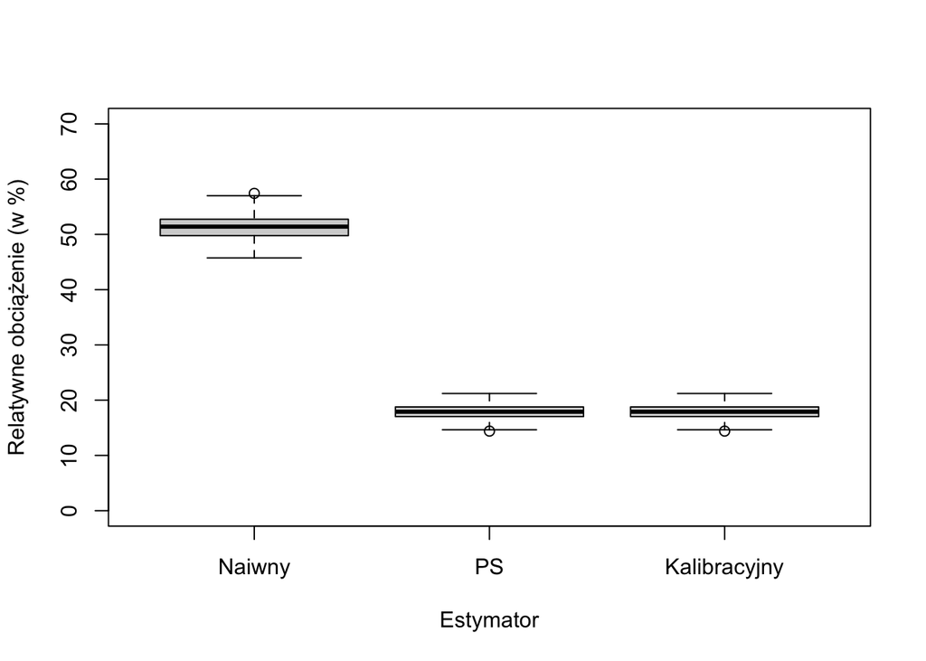

```r
set.seed(1234)
R <- 500
y_naive <- numeric(R)
y_ps <- numeric(R)
y_cal <- numeric(R)
totale <- xtabs(~X1+X2 , data = df)
for (r in 1:500) {
  nb_inds <- sample(1:N, size = nb, prob = abs(Y)/sum(abs(Y)))
  flag <- 1:N %in% nb_inds
  w_star <- N/nb ## dodajemy pseudo-wagę jako relację miedzy N / nb
  df <- data.frame(Y,X1,X2,flag,w_star)
  df$X1 <- as.factor(df$X1)
  df$X2 <- as.factor(df$X2)
  dd <- svydesign(ids= ~1, weights = ~w_star, data = subset(df, flag == T))
  dd2 <- postStratify(dd, strata= ~X1+X2, population = totale)
  dd3 <- calibrate(dd, formula= list(~X1+X2), population = list(totale))


  y_naive[r] <- svymean(~Y, dd)[1]
  y_ps[r] <- svymean(~Y, dd2)[1]
  y_cal[r] <- svymean(~Y, dd2)[1]
}

boxplot((cbind("Naiwny"=y_naive, "PS"=y_ps, "Kalibracyjny"=y_cal) - mean(Y))/mean(Y)*100,
        xlab = "Estymator", ylab = "Relatywne obciążenie (w %)",
        ylim = c(0, 70))
```

Wyniki symulacji

```r
oszacowanie <- c(mean(y_naive), mean(y_ps), mean(y_cal))
obciazenie <- oszacowanie -mean(Y)
wariancja <- c(var(y_naive), var(y_ps), var(y_cal))
rmse <- sqrt(obciazenie^2+wariancja)
data.frame(estymator=c("Naiwny", "PS", "Kalibracyjny"), oszacowanie, obciazenie, wariancja, rmse)
```

```
     estymator oszacowanie obciazenie    wariancja      rmse
1       Naiwny    3.755280  1.2727324 0.0028579428 1.2738546
2           PS    2.925925  0.4433774 0.0009224633 0.4444165
3 Kalibracyjny    2.925925  0.4433774 0.0009224633 0.4444165
```

# 4 Podsumowanie